# RegressionModel_Week4_Project

Deborah Passey

7/12/2019

EXECUTIVE SUMMARY

Research Question 1: Is an automatic or manual transmission better for miles per gallon (MPG)?

##### The dependent variable, miles per gallon, is a continuous variable, so we will use a linear regression model. The independent variable transmission is binary. It appears that some variables might be confounders and should be adjusted for in the linear rgression model. There are two models considered in this analysis:

##### Model 1: indicates that the manual transmission has a significantly higher mile per gallon compared to the automatic tranmission (7.245 mpg higher; p=0.0002).

##### Model 2: indicates that after adjusting for number of cylinders, weight, and horsepower, there is no significant difference between the manual and automatic transmission in miles per gallon.

|  | mpg |  |  | mpg |  |  |
| --- | --- | --- | --- | --- | --- | --- |
| Predictors | Estimates | CI | p | Estimates | CI | p |
| (Intercept) | 17.15 | 14.94 – 19.35 | **<0.001** | 33.71 | 28.60 – 38.81 | **<0.001** |
| Manual | 7.24 | 3.79 – 10.70 | **<0.001** | 1.81 | -0.93 – 4.55 | 0.206 |
| 6cyl |  |  |  | -3.03 | -5.79 – -0.27 | **0.041** |
| 8cyl |  |  |  | -2.16 | -6.64 – 2.31 | 0.352 |
| wt |  |  |  | -2.50 | -4.23 – -0.76 | **0.009** |
| hp |  |  |  | -0.03 | -0.06 – -0.01 | **0.027** |
| Observations | 32 |  |  | 32 |  |  |
| R<sup>2</sup> / adjusted R<sup>2</sup> | 0.360 / 0.338 |  |  | 0.866 / 0.840 |  |  |

##### To compare Model 1 and Model 2, an Analysis of Variance (ANOVA) was used. The ANOVA can be found in Appendix 1.2. The p-value for the ANOVA tests whether the adjustment variables are necessary. The ANOVA indicates that Model 2 with the adjustment variables is necessary over Model 1. From these results, the adjustment variables are necessary, and adjusting for these variables indicate that there is not a significant difference in miles per gallon when comparing the automatic and manual transmissions. The residual plots of Models 1 and 2 can be found in Appendix 1.2.

Research Question 2: What is the difference between automatic and manual transmissions?

1974 Motor Trend, averages by Transmission, 0=automatic, 1=manual

| am | mpg | cyl | disp | hp | drat | wt | qsec | vs | gear | carb |
| --- | --- | --- | --- | --- | --- | --- | --- | --- | --- | --- |
| 0 | 17.14737 | 6.947368 | 290.3789 | 160.2632 | 3.286316 | 3.768895 | 18.18316 | 0.3684211 | 3.210526 | 2.736842 |
| 1 | 24.39231 | 5.076923 | 143.5308 | 126.8462 | 4.050000 | 2.411000 | 17.36000 | 0.5384615 | 4.384615 | 2.923077 |

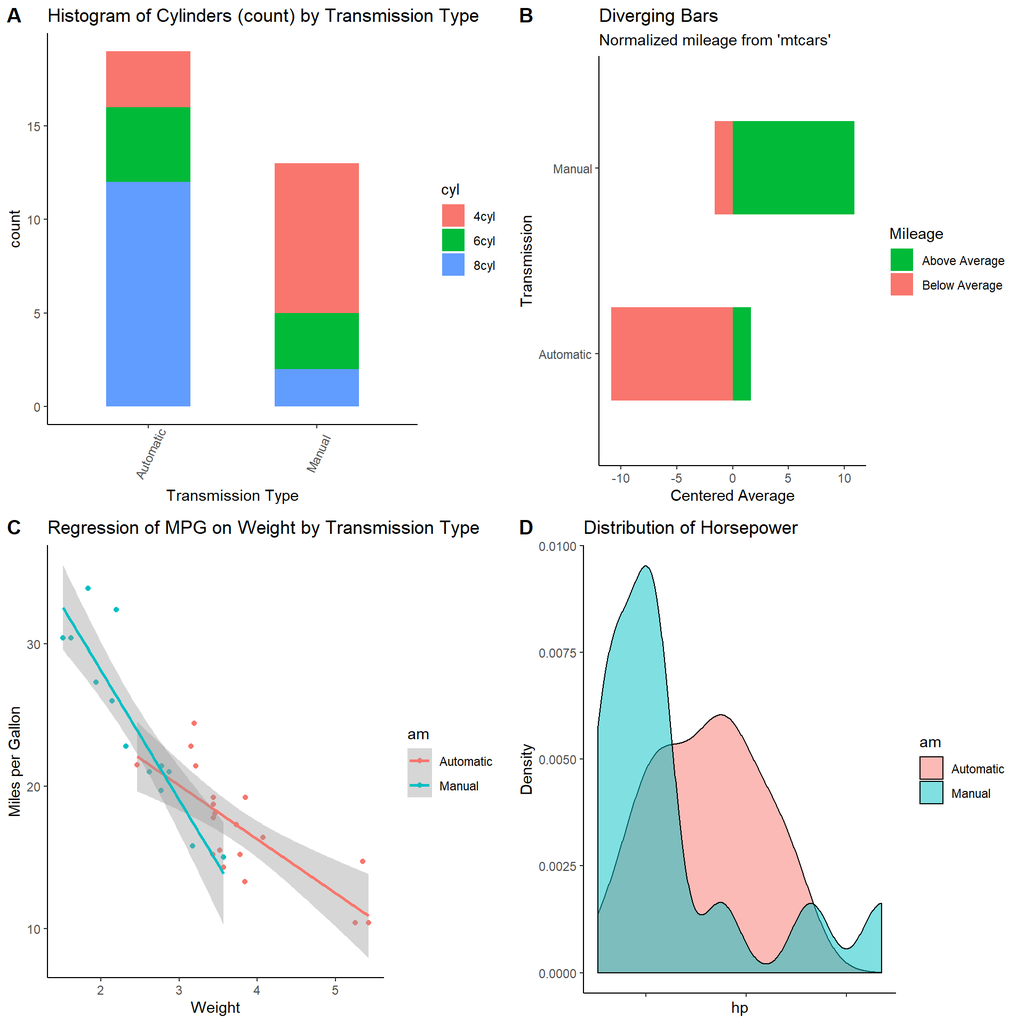

APPENDIX

Appendix 1.1

##### The data comes from Henderson and Velleman (1981), which extracted data from the 1974 Motor Trend US magazine, and comprises fuel consumption and 10 aspects of automobile design and performance for 32 automobiles (1973–74 models). The variables in this data set include: Miles per gallon (mpg), Number of cylinders (cyl), Displacement cubic inch (disp), Gross horsepower (hp), Rear axle ratio (drat), Weight in 1000 lbs (wt), 1/4 mile time (qsec), Engine (vs; 0 = V-shaped, 1 = straight), Transmission (am; 0 = automatic, 1 = manual), Number of forward gears (gear), and Number of carburetors (carb). Data source: Henderson and Velleman (1981), Building multiple regression models interactively. Biometrics, 37, 391–411.

Appendix 1.2: ANOVA and Residual Plots for Question 1

```r
anova(model1, model2)
```

```
## Analysis of Variance Table
##
## Model 1: mpg ~ am
## Model 2: mpg ~ am + cyl + wt + hp
##   Res.Df    RSS Df Sum of Sq      F    Pr(>F)
## 1     30 720.90
## 2     26 151.03  4    569.87 24.527 1.688e-08 ***
## ---
## Signif. codes:  0 '***' 0.001 '**' 0.01 '*' 0.05 '.' 0.1 ' ' 1
```

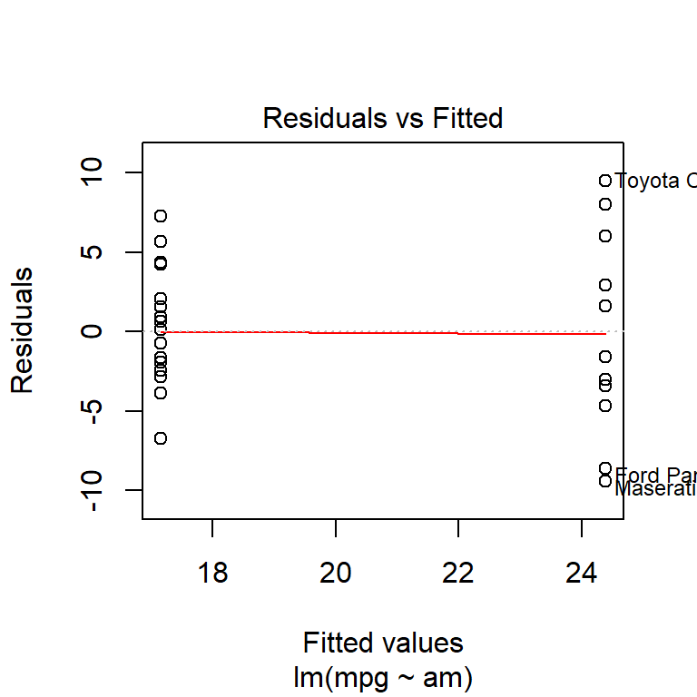

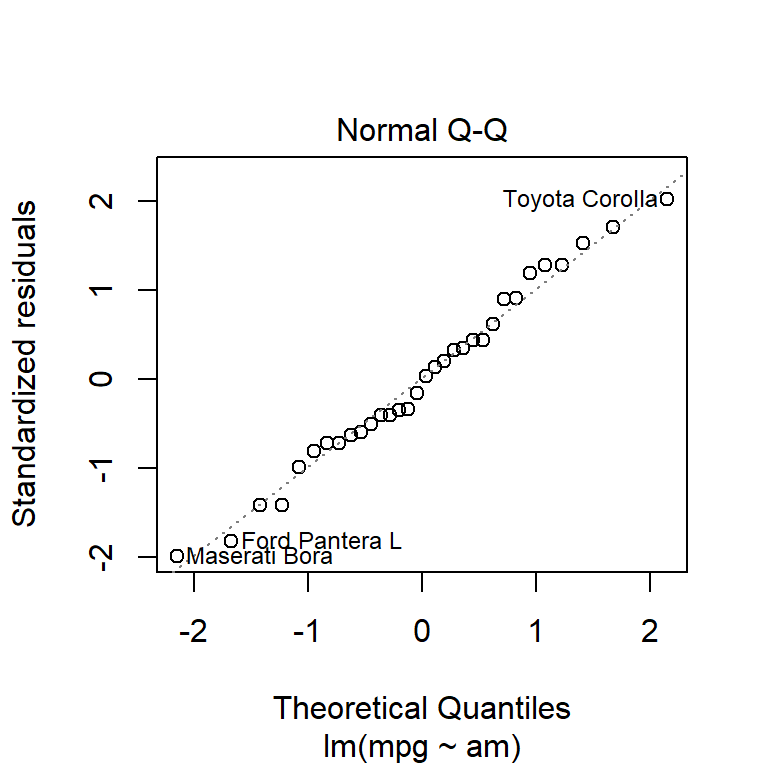

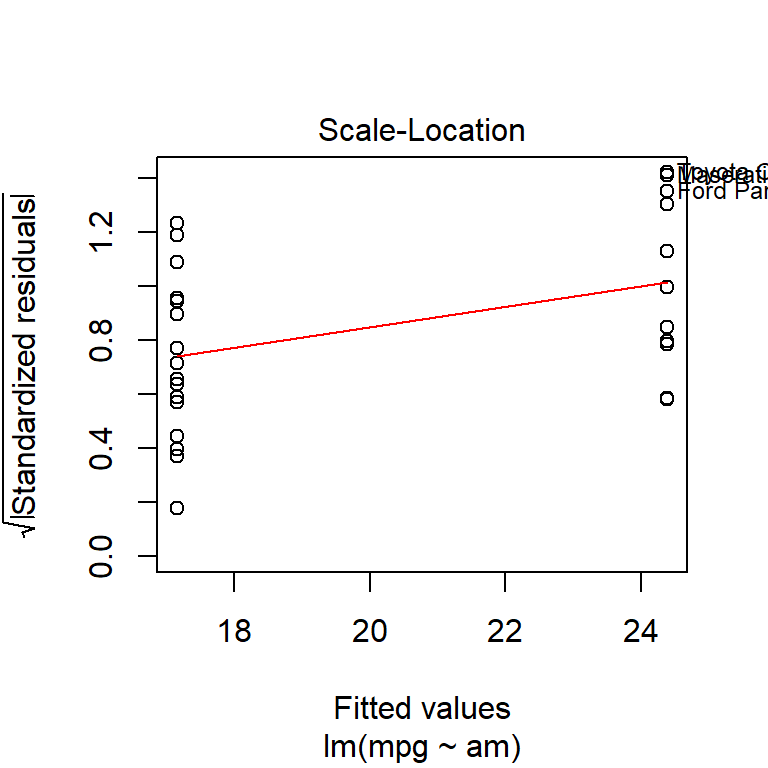

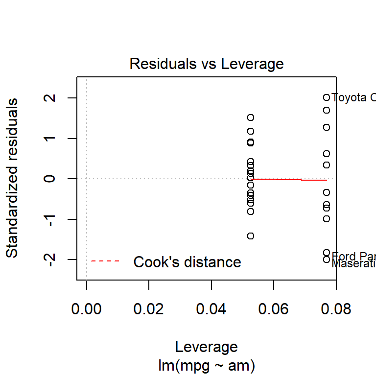

```r
plot(model1)
```

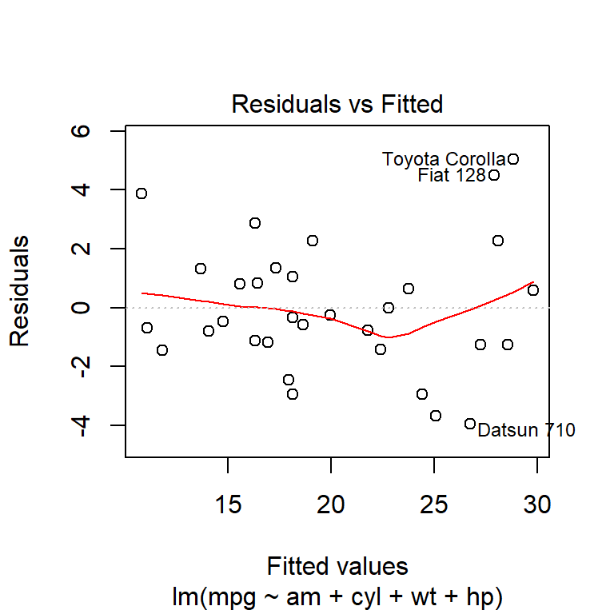

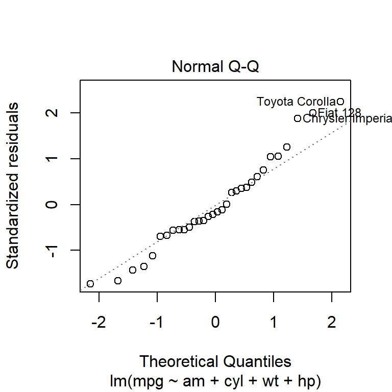

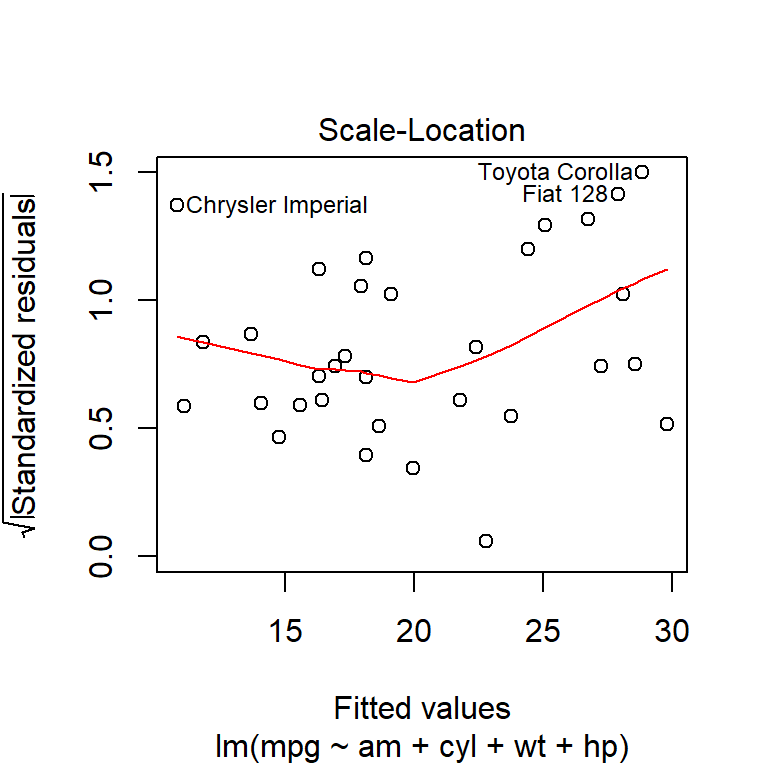

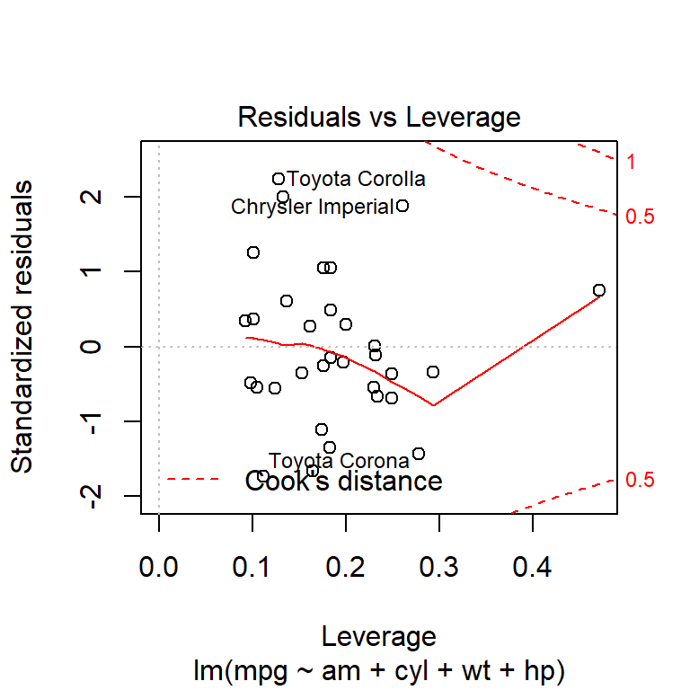

```r
plot(model2)
```

Appendix 1.3: Descriptive data for the data set

```r
kable(mtcars, caption="1974 Motor Trend Car Data") %>%
  kable_styling(bootstrap_options = "striped", full_width = F, position = "left")
```

1974 Motor Trend Car Data

|  | mpg | cyl | disp | hp | drat | wt | qsec | vs | am | gear | carb | mpg_z | mpg_type |
| --- | --- | --- | --- | --- | --- | --- | --- | --- | --- | --- | --- | --- | --- |
| Cadillac Fleetwood | 10.4 | 8cyl | 472.0 | 205 | 2.93 | 5.250 | 17.98 | 0 | Automatic | 3 | 4 | -1.61 | below |
| Lincoln Continental | 10.4 | 8cyl | 460.0 | 215 | 3.00 | 5.424 | 17.82 | 0 | Automatic | 3 | 4 | -1.61 | below |
| Camaro Z28 | 13.3 | 8cyl | 350.0 | 245 | 3.73 | 3.840 | 15.41 | 0 | Automatic | 3 | 4 | -1.13 | below |
| Duster 360 | 14.3 | 8cyl | 360.0 | 245 | 3.21 | 3.570 | 15.84 | 0 | Automatic | 3 | 4 | -0.96 | below |
| Chrysler Imperial | 14.7 | 8cyl | 440.0 | 230 | 3.23 | 5.345 | 17.42 | 0 | Automatic | 3 | 4 | -0.89 | below |
| Maserati Bora | 15.0 | 8cyl | 301.0 | 335 | 3.54 | 3.570 | 14.60 | 0 | Manual | 5 | 8 | -0.84 | below |
| Merc 450SLC | 15.2 | 8cyl | 275.8 | 180 | 3.07 | 3.780 | 18.00 | 0 | Automatic | 3 | 3 | -0.81 | below |
| AMC Javelin | 15.2 | 8cyl | 304.0 | 150 | 3.15 | 3.435 | 17.30 | 0 | Automatic | 3 | 2 | -0.81 | below |
| Dodge Challenger | 15.5 | 8cyl | 318.0 | 150 | 2.76 | 3.520 | 16.87 | 0 | Automatic | 3 | 2 | -0.76 | below |
| Ford Pantera L | 15.8 | 8cyl | 351.0 | 264 | 4.22 | 3.170 | 14.50 | 0 | Manual | 5 | 4 | -0.71 | below |
| Merc 450SE | 16.4 | 8cyl | 275.8 | 180 | 3.07 | 4.070 | 17.40 | 0 | Automatic | 3 | 3 | -0.61 | below |
| Merc 450SL | 17.3 | 8cyl | 275.8 | 180 | 3.07 | 3.730 | 17.60 | 0 | Automatic | 3 | 3 | -0.46 | below |
| Merc 280C | 17.8 | 6cyl | 167.6 | 123 | 3.92 | 3.440 | 18.90 | 1 | Automatic | 4 | 4 | -0.38 | below |
| Valiant | 18.1 | 6cyl | 225.0 | 105 | 2.76 | 3.460 | 20.22 | 1 | Automatic | 3 | 1 | -0.33 | below |
| Hornet Sportabout | 18.7 | 8cyl | 360.0 | 175 | 3.15 | 3.440 | 17.02 | 0 | Automatic | 3 | 2 | -0.23 | below |
| Merc 280 | 19.2 | 6cyl | 167.6 | 123 | 3.92 | 3.440 | 18.30 | 1 | Automatic | 4 | 4 | -0.15 | below |
| Pontiac Firebird | 19.2 | 8cyl | 400.0 | 175 | 3.08 | 3.845 | 17.05 | 0 | Automatic | 3 | 2 | -0.15 | below |
| Ferrari Dino | 19.7 | 6cyl | 145.0 | 175 | 3.62 | 2.770 | 15.50 | 0 | Manual | 5 | 6 | -0.06 | below |
| Mazda RX4 | 21.0 | 6cyl | 160.0 | 110 | 3.90 | 2.620 | 16.46 | 0 | Manual | 4 | 4 | 0.15 | above |
| Mazda RX4 Wag | 21.0 | 6cyl | 160.0 | 110 | 3.90 | 2.875 | 17.02 | 0 | Manual | 4 | 4 | 0.15 | above |
| Hornet 4 Drive | 21.4 | 6cyl | 258.0 | 110 | 3.08 | 3.215 | 19.44 | 1 | Automatic | 3 | 1 | 0.22 | above |
| Volvo 142E | 21.4 | 4cyl | 121.0 | 109 | 4.11 | 2.780 | 18.60 | 1 | Manual | 4 | 2 | 0.22 | above |
| Toyota Corona | 21.5 | 4cyl | 120.1 | 97 | 3.70 | 2.465 | 20.01 | 1 | Automatic | 3 | 1 | 0.23 | above |
| Datsun 710 | 22.8 | 4cyl | 108.0 | 93 | 3.85 | 2.320 | 18.61 | 1 | Manual | 4 | 1 | 0.45 | above |
| Merc 230 | 22.8 | 4cyl | 140.8 | 95 | 3.92 | 3.150 | 22.90 | 1 | Automatic | 4 | 2 | 0.45 | above |
| Merc 240D | 24.4 | 4cyl | 146.7 | 62 | 3.69 | 3.190 | 20.00 | 1 | Automatic | 4 | 2 | 0.72 | above |
| Porsche 914-2 | 26.0 | 4cyl | 120.3 | 91 | 4.43 | 2.140 | 16.70 | 0 | Manual | 5 | 2 | 0.98 | above |
| Fiat X1-9 | 27.3 | 4cyl | 79.0 | 66 | 4.08 | 1.935 | 18.90 | 1 | Manual | 4 | 1 | 1.20 | above |
| Honda Civic | 30.4 | 4cyl | 75.7 | 52 | 4.93 | 1.615 | 18.52 | 1 | Manual | 4 | 2 | 1.71 | above |
| Lotus Europa | 30.4 | 4cyl | 95.1 | 113 | 3.77 | 1.513 | 16.90 | 1 | Manual | 5 | 2 | 1.71 | above |
| Fiat 128 | 32.4 | 4cyl | 78.7 | 66 | 4.08 | 2.200 | 19.47 | 1 | Manual | 4 | 1 | 2.04 | above |
| Toyota Corolla | 33.9 | 4cyl | 71.1 | 65 | 4.22 | 1.835 | 19.90 | 1 | Manual | 4 | 1 | 2.29 | above |